# lab7_part3_mf

Meghan Fletcher

2/17/2021

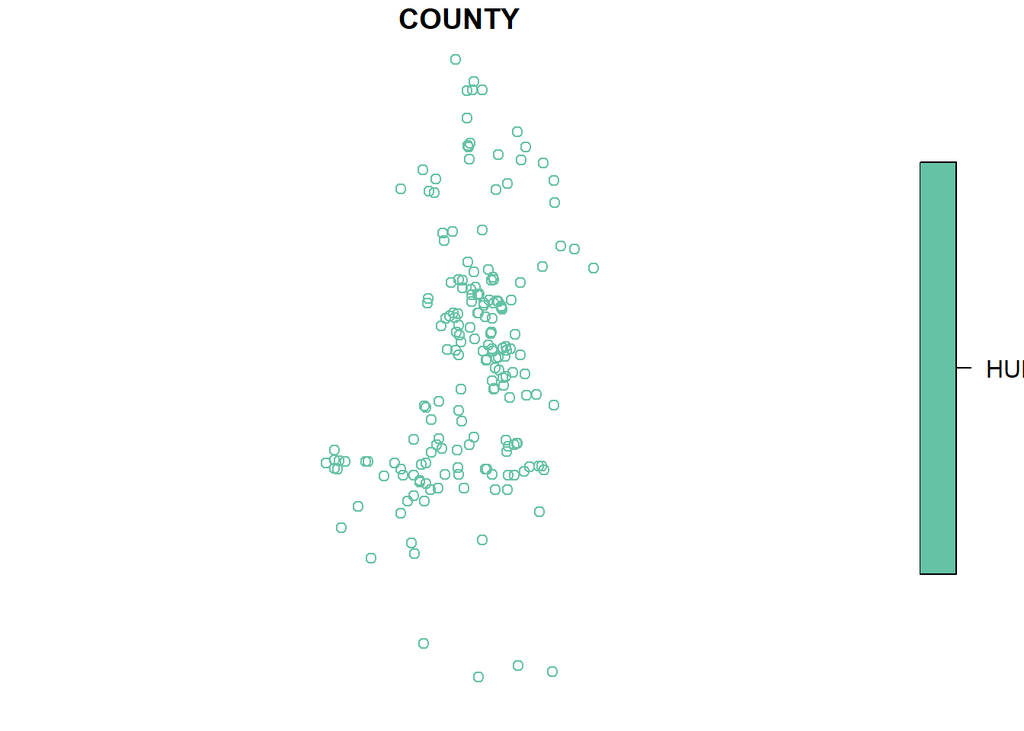

```r
# Read in the tree vole data
voles <- read_sf(dsn = here("redtreevoledata"),
                 layer = "ds033") %>%
  dplyr::select(COUNTY) %>% # Only select the county attribute
  filter(COUNTY == "HUM") %>% # Only keep observations in Humboldt County
  st_transform(crs = 4326) # Update CRS

# Plot it (exploratory)
plot(voles)
```

```r
# Get Humboldt County outline
humboldt <- read_sf(dsn = here("redtreevoledata"),
                    layer = "california_county_shape_file") %>%
  filter(NAME == "Humboldt") %>% # Isolate Humboldt County
  dplyr::select(NAME) # Only keep one attribute (name) to simplify

# Set CRS
st_crs(humboldt) <- 4326 # Set CRS to match
```

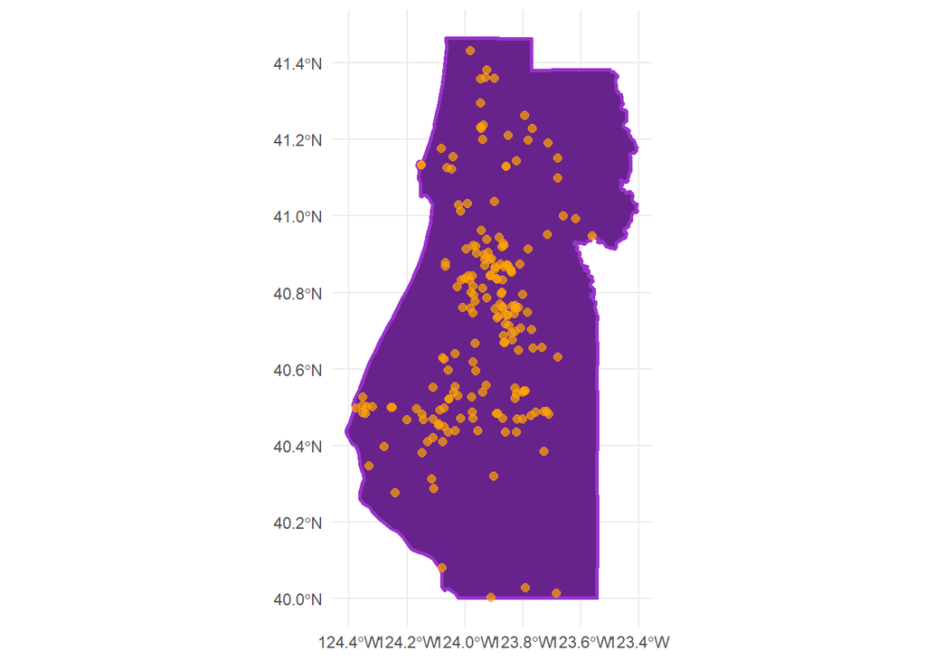

```r
# plot them together
ggplot() +
  geom_sf(data = humboldt,
          color = "darkorchid",
          fill = "darkorchid4",
          size = 1) +
  geom_sf(data = voles,
          color = "orange",
          alpha = 0.7,
          size = 2) +
  theme_minimal()
```

These need to be combined into spatial point pattern data (points + window combo), and for point pattern analysis this **requires a 2D projection** (in this case, UTM), which is why there’s this `proj4string` line here to specify the project

```r
voles_sp <- as(voles,"Spatial") # Convert to object 'Spatial'
proj4string(voles_sp) <- "+proj=utm +zone=10 +datum=WGS84 +units=m +no_defs +ellps=WGS84 +towgs84=0,0,0" # Add UTM projection so that it's 2D (otherwise point pattern analysis invalid)
voles_ppp <- as(voles_sp, "ppp") # Convert to spatial point pattern

humboldt_sp <- as(humboldt, "Spatial") # Convert to object 'Spatial'
proj4string(humboldt_sp) <- "+proj=utm +zone=10 +datum=WGS84 +units=m +no_defs +ellps=WGS84 +towgs84=0,0,0" # Add UTM projection
humboldt_win <- as(humboldt_sp, "owin") # Convert to spatial point pattern

# Combine as a point pattern object (points + window):
voles_full <- ppp(voles_ppp$x, voles_ppp$y, window = humboldt_win)
```

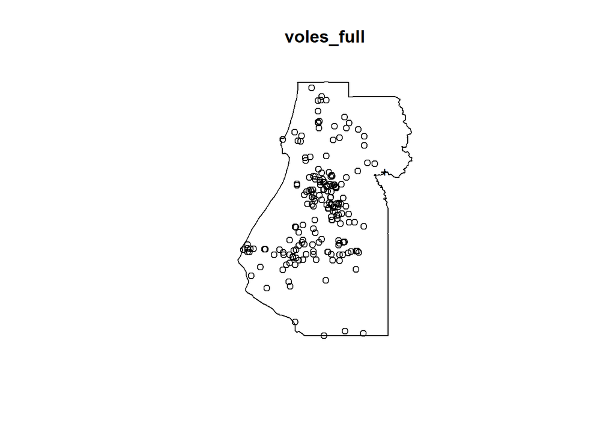

```r
plot(voles_full) # Illegal point (outside window) shows up as the plus sign
```

## Make a kernel density plot:

### Density

Run to see vole “hotspots” by kernel density - see what happens when change sigma - (density gets more refined the smaller sigma is)

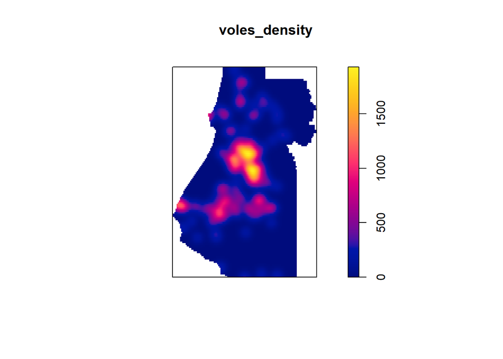

```r
voles_density <- density(voles_full, sigma = 0.03)

plot(voles_density)
```

### Compare to complete spatial randomness

```r
# Can you start viewing this in tmap? Yes, rasterize it:
wgs84 = "+proj=longlat +ellps=WGS84 +datum=WGS84 +no_defs"
vole_raster <- raster(voles_density, crs = wgs84)

# plot:
tmap_mode("view")
```

```
## tmap mode set to interactive viewing
```

```r
tm_shape(vole_raster) +
  tm_raster(midpoint = NA,
            palette = "Reds",
            legend.show = FALSE)
```

[interactive chart not shown]

## Nearest neighbor (G-function)

use both the G- and L-functions (L function is the K-function, standardized…interpretation is the same) to compare our observed point pattern to a simulated CSR scenario, to help us determine if it is *more clustered* or *more uniform* than CSR.

- `r`: a sequence of distances (in the spatial units of the data) over which we’ll calculate the proportion of points with nearest neighbor within that range
- `gfunction`: This uses the `envelope()` function within which we run simulations for CSR, *and* calculate the G-function value at distances *r* for each simulation.
- The `nsim = 100` here means there will be 100 simulations of CSR.
- The `nrank = 2` means that the second highest and second lowest values from simulations are shown as the “hi” and “lo” value envelopes, with the “theo” being the “theoretical value of the summary function under CSR (Complete Spatial Randomness, a uniform Poisson point process) if the simulations were generated according to CSR.”
- Basically, we are comparing the “observed” data to the “theoretical CSR” here, and those “hi” and “lo” envelope bounds give us an idea of spread for the simulations.

```r
r <- seq(0,0.15, by = 0.005) # Make a sequence of distances over which you'll calculate G(r)

gfunction <- envelope(voles_full, fun = Gest, r = r, nsim = 100, nrank = 2) # Calculate the actual and theoretical G(r) values, using 100 simulations of CRS for the "theoretical" outcome
```

```
## Generating 100 simulations of CSR  ...
## 1, 2, 3, 4, 5, 6, 7, 8, 9, 10, 11, 12, 13, 14, 15, 16, 17, 18, 19, 20, 21, 22, 23, 24, 25, 26, 27, 28, 29, 30, 31, 32, 33, 34, 35, 36, 37, 38, 39, 40,
## 41, 42, 43, 44, 45, 46, 47, 48, 49, 50, 51, 52, 53, 54, 55, 56, 57, 58, 59, 60, 61, 62, 63, 64, 65, 66, 67, 68, 69, 70, 71, 72, 73, 74, 75, 76, 77, 78, 79, 80,
## 81, 82, 83, 84, 85, 86, 87, 88, 89, 90, 91, 92, 93, 94, 95, 96, 97, 98, 99,  100.
##
## Done.
```

```r
gfunction # << Check the output of gfunction, then...
```

```
## Pointwise critical envelopes for G(r)
## and observed value for 'voles_full'
## Edge correction: "km"
## Obtained from 100 simulations of CSR
## Alternative: two.sided
## Significance level of pointwise Monte Carlo test: 4/101 = 0.0396
## .....................................................................
##      Math.label     Description
## r    r              distance argument r
## obs  hat(G)[obs](r) observed value of G(r) for data pattern
## theo G[theo](r)     theoretical value of G(r) for CSR
## lo   hat(G)[lo](r)  lower pointwise envelope of G(r) from simulations
## hi   hat(G)[hi](r)  upper pointwise envelope of G(r) from simulations
## .....................................................................
## Default plot formula:  .~r
## where "." stands for 'obs', 'theo', 'hi', 'lo'
## Columns 'lo' and 'hi' will be plotted as shading (by default)
## Recommended range of argument r: [0, 0.04]
## Available range of argument r: [0, 0.15]
```

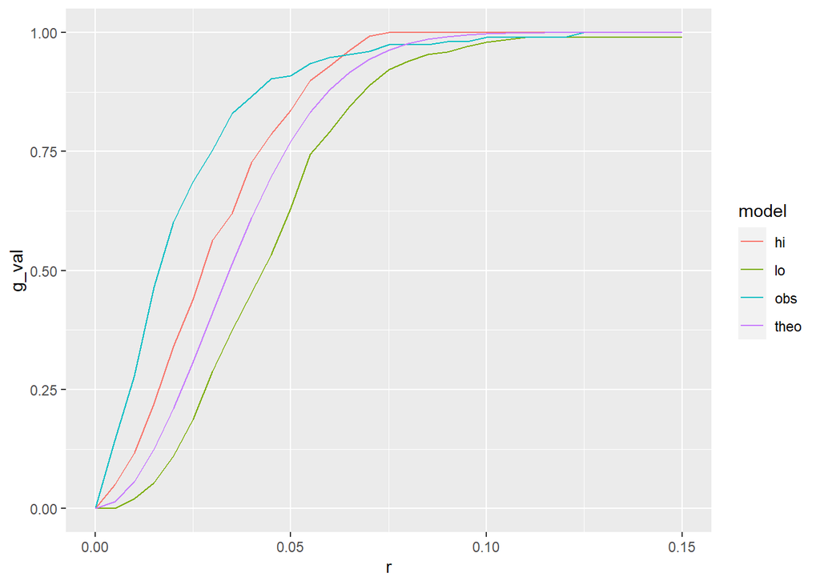

```r
# Gather this to plot series in ggplot:
gfunction_long <- gfunction %>%
  as.data.frame() %>%
  pivot_longer(cols = obs:hi, names_to = "model", values_to = "g_val")

# Then make a graph in ggplot:
ggplot(data = gfunction_long, aes(x = r, y = g_val, group = model)) +
  geom_line(aes(color = model))
```

This again confirms clustering - our data (model = obs) has a greater proportion of events with nearest neighbor at *smaller distances* compared to a theoretical CSR scenario (model = theo). But remember, the G-function only considers the single nearest neighbor.

- **L-function (standardized K-function)** which considers densities of observations within some distance R (expanding circles around each point) for comparison.
- now the function is `Lest` for “L estimate”, which calculates the density of events within growing circles around *each point*.
- That is much more intensive than just the single nearest neighbor, so run `nsim = 10` here instead

```r
r2 <- seq(0, 0.5, by = 0.05)

lfunction <- envelope(voles_full, fun = Lest, r = r2, nsim = 10, rank = 2, global = TRUE)
```

```
## Generating 10 simulations of CSR  ...
## 1, 2, 3, 4, 5, 6, 7, 8, 9,  10.
##
## Done.
```

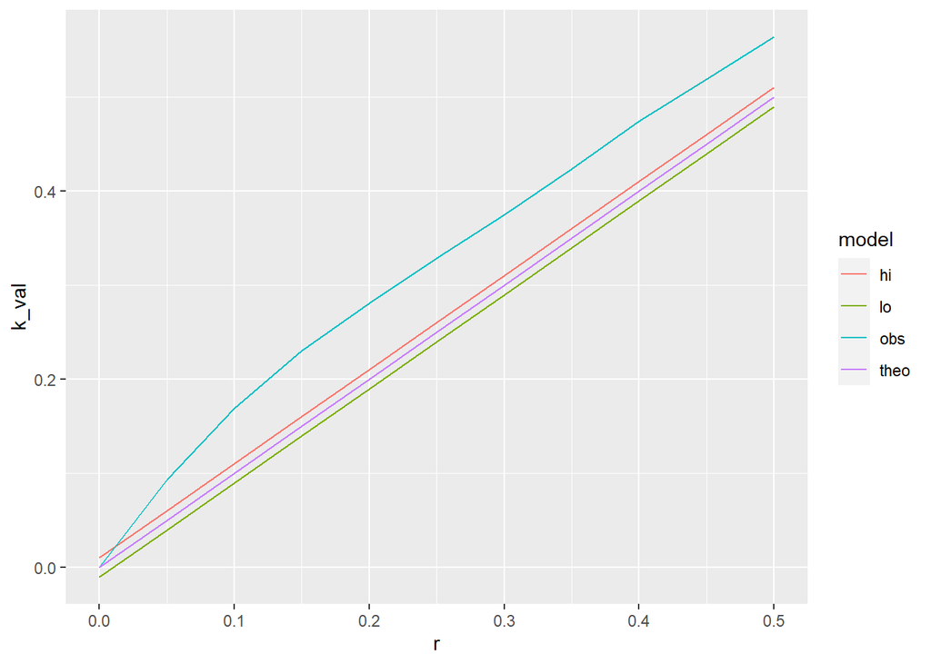

```r
# Gather this to plot series in ggplot:
lfunction_long <- lfunction %>%
  as.data.frame() %>%
  pivot_longer(cols = obs:hi, names_to = "model", values_to = "k_val")

ggplot(data = lfunction_long, aes(x = r, y = k_val, group = model)) +
  geom_line(aes(color = model))
```

We again see that at lower distances, our data overall has a higher density of nearest neighbors compared to a simulated CSR scenario. Again, evidence of clustering.